# Basketball Foul Calls

Shusei Yokoi

An article by K. J. Anderson and Pierce (2009) describes empirical evidence that officials in NCAA men’s college basketball tend to “even out” foul calls over the course of a game, based on data collected in 2004-2005. Using logistic regression to model the effect of foul differential on the probability that the next foul called would be on the home team (controlling for score differential, conference, and whether or not the home team had the lead), they found that “the probability of the next foul being called on the visiting team can reach as high as 0.70.” More recently, Moskowitz and Wertheim (2011), in their book Scorecasting, argue that the number one reason for the home field advantage in sports is referee bias. Specifically, in basketball, they demonstrate that calls over which referees have greater control—offensive fouls, loose ball fouls, ambiguous turnovers such as palming and traveling—were more likely to benefit the home team than more clear-cut calls, especially in crucial situations. In this exercise, you will examine data collected by Noecker and Roback from the 2009-2010 basketball season for the first half of 340 games in the Big Ten, ACC, and Big East conferences. The basketball0910.txt data file has a row for each of 4,972 fouls. The primary response variable is foul.home, 1 if the foul was called on the home team. The hypothesis is that if more fouls have been called on the home team than the visiting team, the probability is smaller that the next foul is on the home team.

```r
bball = read.delim("http://rossmanchance.com/stat414/data/basketball0910.txt", "\t", header=TRUE)
```

**Fitting a “naïve” Logistic Regression Model**

```r
summary(glm(formula = foul.home ~ foul.diff, family = binomial, data = bball))
```

```
##
## Call:
## glm(formula = foul.home ~ foul.diff, family = binomial, data = bball)
##
## Deviance Residuals:
##     Min       1Q   Median       3Q      Max
## -1.5817  -1.1227  -0.9654   1.1772   1.5225
##
## Coefficients:
##             Estimate Std. Error z value Pr(>|z|)
## (Intercept) -0.13005    0.02912  -4.466 7.98e-06 ***
## foul.diff   -0.13047    0.01426  -9.148  < 2e-16 ***
## ---
## Signif. codes:  0 '***' 0.001 '**' 0.01 '*' 0.05 '.' 0.1 ' ' 1
##
## (Dispersion parameter for binomial family taken to be 1)
##
##     Null deviance: 6884.3  on 4971  degrees of freedom
## Residual deviance: 6798.1  on 4970  degrees of freedom
## AIC: 6802.1
##
## Number of Fisher Scoring iterations: 4
```

As one difference in foul increase for visitor (diff = 1), 12.23% (1-exp(-0.13047)) decrease the chance for next foul would be call for home.

**Add Random Slopes**

```r
summary(glmer(foul.home ~ foul.diff + (foul.diff | game), family = binomial, data = bball) )
```

```
## boundary (singular) fit: see ?isSingular
```

```
## Generalized linear mixed model fit by maximum likelihood (Laplace
##   Approximation) [glmerMod]
##  Family: binomial  ( logit )
## Formula: foul.home ~ foul.diff + (foul.diff | game)
##    Data: bball
##
##      AIC      BIC   logLik deviance df.resid
##   6791.1   6823.6  -3390.5   6781.1     4967
##
## Scaled residuals:
##     Min      1Q  Median      3Q     Max
## -1.6399 -0.9087 -0.6349  0.9528  1.7687
##
## Random effects:
##  Groups Name        Variance Std.Dev. Corr
##  game   (Intercept) 0.294141 0.54235
##         foul.diff   0.001235 0.03514  -1.00
## Number of obs: 4972, groups:  game, 340
##
## Fixed effects:
##             Estimate Std. Error z value Pr(>|z|)
## (Intercept) -0.15684    0.04637  -3.382 0.000719 ***
## foul.diff   -0.28533    0.03835  -7.440 1.01e-13 ***
## ---
## Signif. codes:  0 '***' 0.001 '**' 0.01 '*' 0.05 '.' 0.1 ' ' 1
##
## Correlation of Fixed Effects:
##           (Intr)
## foul.diff 0.192
## convergence code: 0
## boundary (singular) fit: see ?isSingular
```

**Consider both game and team as Level 2 units with random effects**

```r
summary(model3 <- glmer(foul.home ~ foul.diff + (1 | game) + (1 | hometeam) + (1 | visitor), family = binomial, data = bball) )
```

```
## Generalized linear mixed model fit by maximum likelihood (Laplace
##   Approximation) [glmerMod]
##  Family: binomial  ( logit )
## Formula: foul.home ~ foul.diff + (1 | game) + (1 | hometeam) + (1 | visitor)
##    Data: bball
##
##      AIC      BIC   logLik deviance df.resid
##   6780.5   6813.0  -3385.2   6770.5     4967
##
## Scaled residuals:
##     Min      1Q  Median      3Q     Max
## -1.6589 -0.9056 -0.6522  0.9679  1.7952
##
## Random effects:
##  Groups   Name        Variance Std.Dev.
##  game     (Intercept) 0.17164  0.4143
##  hometeam (Intercept) 0.06809  0.2609
##  visitor  (Intercept) 0.02323  0.1524
## Number of obs: 4972, groups:  game, 340; hometeam, 39; visitor, 39
##
## Fixed effects:
##             Estimate Std. Error z value Pr(>|z|)
## (Intercept) -0.18780    0.06331  -2.967  0.00301 **
## foul.diff   -0.26385    0.03883  -6.795 1.09e-11 ***
## ---
## Signif. codes:  0 '***' 0.001 '**' 0.01 '*' 0.05 '.' 0.1 ' ' 1
##
## Correlation of Fixed Effects:
##           (Intr)
## foul.diff 0.256
```

Interpret the five estimated parameters.  
**Fixed**:  
Intercept: Predicted percentage of foul call for home team when there is not different number of foul calls is 45.3%.  
slope(foul.diff): As one difference in foul increase for visitor (diff = 1), 23.2% (1-exp(-0.26385)) decrease the chance for next foul would be call for home.  
**Random**:  
Intercept(game): Average probability variance between games when score diff = 0 is 0.17164  
Intercept(hometeam): Average probability variance between hometeams when score diff = 0 is 0.06809  
Intercept(visitor): Average probability variance between visitors when score diff = 0 is 0.02323

**Variation**  
game to game: 0.17164 / (0.17164+3.29) = 0.0495834  
team to team: 0.06809 / (0.17164+3.29) = 0.0196699  
vis team to vis team: 0.02323 / (0.17164+3.29) = 0.0067107

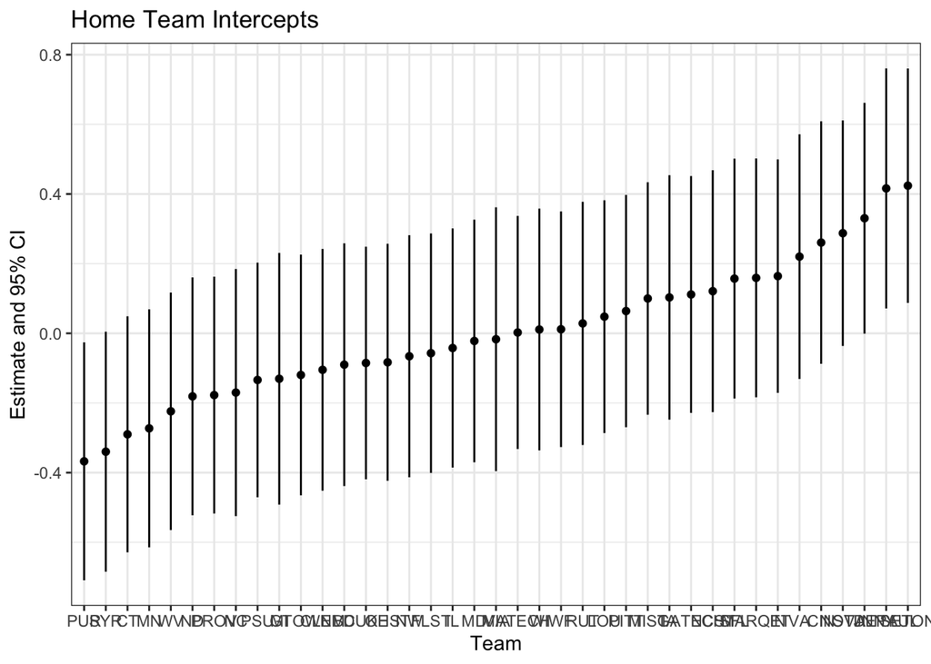

```r
u0 <- as.data.frame(ranef(model3, condVar = TRUE) )

ggplot(u0[u0$grpvar=="hometeam",], aes(y = condval, x = grp)) +
  geom_point() +
  geom_errorbar(aes(ymin = condval - 1.96*condsd,
                    max = condval + 1.96*condsd), width = 0) +
  labs(title = "Home Team Intercepts",  x = "Team", y = "Estimate and 95% CI") +
  theme(axis.text.x = element_text(angle = 90)) +  theme_bw()
```

```r
ranef(model3)$hometeam
```

|  | (Intercept) |
| --- | --- |
| BC | -0.090041459 |
| CIN | 0.260564527 |
| CLEM | -0.104818582 |
| CT | -0.289979922 |
| DEPAUL | 0.416051893 |
| DUKE | -0.085231143 |
| FLST | -0.057060282 |
| GATECH | 0.111525117 |
| GTOWN | -0.119608598 |
| IA | 0.103035986 |

[output cut: 29 more lines]

Intercept: Predicted percentage of foul call for home team when there is not different number of foul calls for SETON is 60.4412886% (exp(0.423886525)/(1+exp(0.423886525))).  
Intercept: Predicted percentage of foul call for home team when there is not different number of foul calls for PUR is 40.912908% (exp(-0.367566879)/(1+exp(-0.367566879))).

**ANOVA Test**

```r
model4=glmer(foul.home ~ foul.diff + (1 | game) , family = binomial, data = bball)

anova(model3, model4)
```

|  | npar | AIC | BIC | logLik | deviance | Chisq | Df | Pr(>Chisq) |
| --- | --- | --- | --- | --- | --- | --- | --- | --- |
| model4 | 3 | 6792.540 | 6812.075 | -3393.270 | 6786.540 | NA | NA | NA |
| model3 | 5 | 6780.466 | 6813.024 | -3385.233 | 6770.466 | 16.07401 | 2 | 0.0003232764 |

Fitting a model that accounts for score differential, whether the home team has the lead, time left in the first half, type of foul, the interaction between foul differential and type of foul, the interaction between foul differential and time.

```r
summary(model5 <- glmer(foul.home ~ foul.diff + score.diff + lead.home +time + foul.type + foul.diff:foul.type +  foul.diff:time + lead.home:time + (1 | game) + (1 | hometeam) + (1 | visitor),  family = binomial,     data = bball))
```

```
## Generalized linear mixed model fit by maximum likelihood (Laplace
##   Approximation) [glmerMod]
##  Family: binomial  ( logit )
## Formula: foul.home ~ foul.diff + score.diff + lead.home + time + foul.type +
##     foul.diff:foul.type + foul.diff:time + lead.home:time + (1 |
##     game) + (1 | hometeam) + (1 | visitor)
##    Data: bball
##
##      AIC      BIC   logLik deviance df.resid
##   6731.0   6822.2  -3351.5   6703.0     4958
##
## Scaled residuals:
##     Min      1Q  Median      3Q     Max
## -2.1273 -0.8956 -0.5830  0.9456  2.6836
##
## Random effects:
##  Groups   Name        Variance Std.Dev.
##  game     (Intercept) 0.18482  0.4299
##  hometeam (Intercept) 0.07833  0.2799
##  visitor  (Intercept) 0.04315  0.2077
## Number of obs: 4972, groups:  game, 340; hometeam, 39; visitor, 39
##
## Fixed effects:
##                              Estimate Std. Error z value Pr(>|z|)
## (Intercept)                 -0.327713   0.157619  -2.079   0.0376 *
## foul.diff                   -0.274897   0.062217  -4.418 9.95e-06 ***
## score.diff                   0.033496   0.008236   4.067 4.76e-05 ***
## lead.home                   -0.149845   0.177215  -0.846   0.3978
## time                        -0.008713   0.008561  -1.018   0.3088
## foul.typePersonal            0.147858   0.108601   1.361   0.1734
## foul.typeShooting            0.080858   0.111233   0.727   0.4673
## foul.diff:foul.typePersonal  0.047672   0.052304   0.911   0.3621
## foul.diff:foul.typeShooting  0.103300   0.053865   1.918   0.0551 .
## foul.diff:time              -0.008697   0.003274  -2.656   0.0079 **
## lead.home:time               0.025940   0.012172   2.131   0.0331 *
## ---
## Signif. codes:  0 '***' 0.001 '**' 0.01 '*' 0.05 '.' 0.1 ' ' 1
##
## Correlation of Fixed Effects:
##             (Intr) fl.dff scr.df led.hm time   fl.tyP fl.tyS fl.:.P fl.:.S
```

[output cut: 8 more lines]

```
## foul.dff:tm -0.019 -0.280 -0.042 -0.008  0.049  0.005  0.014 -0.004 -0.012
## lead.hom:tm  0.471 -0.040  0.385 -0.828 -0.743 -0.001  0.011  0.005  0.008
##             fl.df:
## foul.diff
## score.diff
## lead.home
## time
## fl.typPrsnl
## fl.typShtng
## fl.dff:fl.P
## fl.dff:fl.S
## foul.dff:tm
## lead.hom:tm  0.024
## convergence code: 0
## Model failed to converge with max|grad| = 0.0134103 (tol = 0.002, component 1)
```

```r
anova(model5)
```

|  | npar | Sum Sq | Mean Sq | F value |
| --- | --- | --- | --- | --- |
| foul.diff | 1 | 244.153136 | 244.153136 | 244.153136 |
| score.diff | 1 | 44.088916 | 44.088916 | 44.088916 |
| lead.home | 1 | 3.206294 | 3.206294 | 3.206294 |
| time | 1 | 1.625221 | 1.625221 | 1.625221 |
| foul.type | 2 | 2.648338 | 1.324169 | 1.324169 |
| foul.diff:foul.type | 2 | 4.871619 | 2.435810 | 2.435810 |
| foul.diff:time | 1 | 7.695270 | 7.695270 | 7.695270 |
| lead.home:time | 1 | 4.681415 | 4.681415 | 4.681415 |

```r
exp(fixef(model5))
```

```
##                 (Intercept)                   foul.diff
##                   0.7205701                   0.7596502
##                  score.diff                   lead.home
##                   1.0340631                   0.8608417
##                        time           foul.typePersonal
##                   0.9913250                   1.1593485
##           foul.typeShooting foul.diff:foul.typePersonal
##                   1.0842167                   1.0488267
## foul.diff:foul.typeShooting              foul.diff:time
##                   1.1088244                   0.9913405
##              lead.home:time
##                   1.0262790
```

foul.diff: Has negative effect on the increase of the home team foul call. (More foul diff cause less foul call probability)  
score.diff: Has positive effect on the increase of the home team foul call (More foul diff cause more foul call probability)  
foul.diff:time: As the time passes (increases), the amount decrease of probability of home team foul call based on foul diff gets bigger.  
lead.home:time: As the time passes, the amount increase of probability of home team foul call based on leads onn home team gets bigger.